# Null space of S and other algebraic characteristics

W. Bauer

June 19, 2015

### Some structure in the null space of S

A system matrix will have a null space of dimension at least n-1, where n is the number of columns of pixels in the associated image. Two such columns are shown in bright yellow in the figure below. Two transmitter-to-receiver paths are also shown. Each path intersects the columns in segments of equal length–4.4 mm for the path from 2 to 8, 4.8 mm for the path from 3 to 2. Of course, it’s a matter of elementary geometry that any line crossing columns of equal width will intersect those columns in segments of the equal length.

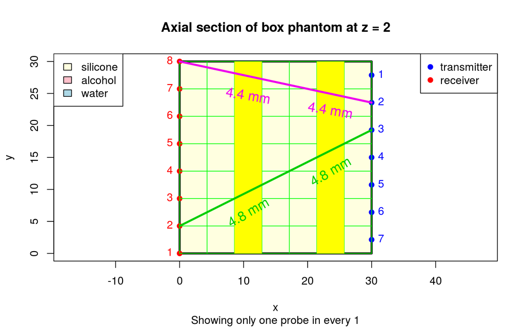

The element, $S_{ij},$ of a system matrix is the length of the $i^{th}$ path through $j^{th}$ pixel. If, for the $i^{th}$ path, the entries corresponding to all pixels in a column of the image are added up, the length of the segment of the $i^{th}$ path through that column of the image results. A vector can be constructed to subtract two such total lengths from one another. The result, of course, will be zero.

For the two columns pictured, and our convention for numbering pixels (i.e., left to right, bottom to top,) such a vector would be 7 repetitions of the vector $(0, 0, 1, 0, 0, -1, 0).$

```r
# Form the system matrix for the setup pictured
S <- createSij(setup)
# Form the vector
v <- rep(c(0, 0, 1, 0, 0, -1, 0), 7)
# Is the maximum absolute value of S %*% v zero within tolerance?
all.equal(max(abs(S %*% v)), 0)
```

```
## [1] TRUE
```

For the case pictured, all vectors of this type can be formed from vectors consisting of 7 repetitions of $(1,-1,0,0,0,0,0),\:(0,1,-1,0,0,0,0),\: \ldots, \: (0,0,0,0,0,1,-1).$ There are 6 such vectors, one less than the number of columns of pixels in the image. The logic easily extends to an arbitrary number, n, of columns. Hence the null space of S is of dimension at least n-1.

It should be noted that vectors of this type could produce artifactual stripes in a recovered image.

It should also be noted the null space of S generally has higher dimension than n-1. For the case pictured, for instance, $S^TS$ has 8 eigenvalues of 0 (within numerical tolerance) which implies that the null space of $S$ has dimension 8, not 6. The origin of the additional null eigenvalues is as yet unclear.

### Algebraic structure resulting from non-negativity

Since the above implies that image recovery from a single scan will always be somewhat indeterminate, it is natural to consider additional constraints. Since all quantities of interest are non-negative, inequality constraints are an obvious choice.

Speeds of sound in human tissue (excluding teeth) vary from about 1400 to about 3300 m/sec. (Source, [Nat’l Physical Lab, UK](http://www.kayelaby.npl.co.uk/general_physics/2_4/2_4_6.html).) Their reciprocals, slowness values, will thus range from about 0.0003 sec/m to about 0.0007 sec/m. Reconstructed images will thus consist of vectors, $b,$ such that $0.0003 \le b \le 0.0007$ componentwise, (i.e., $0.0003 \le b_j \le 0.0007$, for each component, $b_j.$)

The polytope, $B,$ consisting of all vectors, $b,$ satisfying $0.0003 \le b \le 0.0007$ is an algebraic structure known as a lattice. That is,

- $B$ is partially ordered under componentwise comparison–If $b \in B$ and $c \in B$, then $b \le c$ if and only if $b_j \le c_j$ for all components, $j.$
- If $b \in B$ and $c \in B$ then their componentwise maximum, written $b \vee c,$ is also in $B.$
- If $b \in B$ and $c \in B$ then their componentwise minimum, written $b \wedge c,$ is aslo in $B.$

$B$ is also convex: if $b \in B,$ $c \in B,$ and $\lambda$ is a scalar between 0 and 1, then $\lambda b + (1-\lambda) c \in B,$ as well.

Since the elements of $S$ are all non-negative, $S$ preserves order on $B.$ If $b \le c$ componentwise, then $Sb \le Sc$ componentwise. Since $b_j \le c_j$ for all components, $j,$ and since $S_{ij} \ge 0$ for all $i$ and $j,$ we have $S_{ij}b_j \le S_{ij}c$ for all $j$, hence $\sum S_{ij}b_j \le \sum S_{ij}c,$ hence $Sb \le Sc$.

The converse is not true; $Sb \le Sc$ does not imply that $b \le c.$ The vectors, $b$ and $c,$ may not be comparable, i.e., some components of $b$ may be bigger than the corresponding components of $c$ and some may be smaller.

The abstract algebraic properties of $B$ and $S[B]$ are probably not of great interest here, but associated algorithmic techniques (e.g., from linear programming, or greedy algorithms) may well be.

### Example: formulation of image recovery as a linear program

Suppose $\tau$ is a vector of time-of-flight measurements and we want to find $b^* \in B$ such that $Sb^* = \tau.$

If $Sb \le \tau$ componentwise, then$(Sb)_j \le \tau_j\:\:for\: all\: j,\\hence \:(Sb)_j\tau_j \le \tau_j^2\:\:for\:all\:j,\\hence\:Sb\bullet \tau \le \tau \bullet \tau\\hence\: b \bullet S^T\tau \le \tau \bullet \tau,$using properties of transpose ($^T$) and inner product ($\bullet$) in the last step.

Thus, $b^*$ can be characterized as maximizing $b \bullet S^T\tau$ subject to the linear inequality constraints, $Sb \le \tau$ and $b \in B.$ Finding $b^*$ is a linear programming problem to which the simplex algorithm applies.

An optimal solution $b^*$ will exist as long as $\tau \in S[B],$ which should be the case as long as slowness values of the phantom or body being scanned are in the assumed range. The problem is not the existence of one optimum, but the existence of many.